# Análise da criminalidade no estado de São Paulo relacionada a População, Educação e Renda

08 outubro, 2021

# 1 Introdução

PROGRAMA DE MENTORIA ENTRE ALUNOS DSA - TURMA 2 - TEMPORADA 2021

## 1.1 Composição da equipe

| Nome | e_mail | Função |
| --- | --- | --- |
| Rogélio Gonçalves Neto | rogelio.neto@uspedra.com.br | Mentor |
| Luciana Silva Albuquerque de Melo | lucianasmf@yahoo.com.br | Mentorado |
| Leticia Fiorina Echeverria Grobério | lele1806@bol.com.br | Mentorado |

## 1.2 Resumo

Para este Programa de Mentoria nossa equipe trabalhou em um projeto que teve como objetivo geral analisar de conjuntos de dados públicos sobre população, educação, renda e criminalidade no Estado de São Paulo a fim de encontrar possíveis correlações que possam corroborar com a tomada de decisão e planejamento estratégico por parte da Segurança Pública do Estado de São Paulo, visto a necessidade de maior agilidade no enfrentamento da criminalidade.

A fim de alcançar o objetivo principal do projeto a equipe seguiu alguns passos que estão listados como objetivos específicos e que propiciou atender, na medida do possível, o objetivo do Programa de Mentoria entre alunos DSA – Temporada - 2021, que é: “Permitir que alunos mais experientes e com perfil de Mentor, ajudem outros alunos indicando caminhos para os objetivos profissionais, guias de estudos, desenvolvimento de soft skills e trabalho em grupo” (DSA,2021).

Os conjuntos de dados foram extraídos por meio do desenvolvimento de um método automático e apresentados em um dashboard desenvolvido em Power BI.

## 1.3 Objetivo do trabalho

Este trabalho tem como objetivo geral a análise de conjuntos de dados públicos sobre população, educação, renda e criminalidade no Estado de São Paulo a fim de encontrar possíveis correlações que possam corroborar com a tomada de decisão e planejamento estratégico por parte da Segurança Pública do Estado de São Paulo e tem como objetivos específicos:

- Trabalhar com o ciclo de vida de ciência de dados;
- Extrair os quatro datasets propostos;
- Demonstrar os dados dos datasets extraídos;
- Apresentar um dashboard das informações;
- Apresentar um arquivo consolidado das informações;

## 1.4 Macro cronograma

| Data Início | Dias | Atividades | Data Fim |
| --- | --- | --- | --- |
| 07/06/2021 | 20 | Definição do tema; | 27/06/2021 |
| - | - | Definição das atividades; | - |
| - | - | Definição do problema; | - |
| 28/06/2021 | 15 | Identificação do site | 13/07/2021 |
| - | - | Identificação das ferramentas | - |
| 14/07/2021 | 15 | Problemas pessoais (quase desistência do projeto) | 29/07/2021 |
| 30/07/2021 | 46 | Desenvolvimento dos robôs; | 14/09/2021 |
| - | - | Análise dos dataset; | - |
| - | - | Desenvolvimento do RMarkdown | - |
| - | - | Desenvolvimento do PowerBI | - |
| 15/09/2021 | 15 | Desenvolvimento da documentação; | 30/09/2021 |
| 01/10/2021 | 3 | Revisão da entrega; | 04/10/2021 |
| - | - | Entrega do trabalho; | - |

Tendo em vista que trata-se de um trabalho acadêmico sem fins profissionais os dados baixados não foram extraídos em sua totalidade e em alguns sites haviam dados faltantes, ou seja, não estavam atualizados com todos os anos, desta forma foi **definido que não iríamos nos preocupar com estes dados faltantes** e sim com os processos de automatização **“criação dos robôs”**, desenvolvimento de uma visualização de entregra e finalizando com o gráficos de demonstração de resultados.

# 2 Apresentação dos dados e informações

Os datasets (ou conjuntos de dados) são os insumo dos processos de análise de dados, representam os dados extraídos de um fonte origem site, sistema, redes sociais e etc. O que foi utilizado neste projeto foram de orgãos publicos do Brasil e do estado de São Paulo.

Em todos os datasets os nomes dos municipíos foram tratados e transformado em caixa alta, retirada a acentuação e realizado acertos diversos.

## 2.1 Origem fonte de dados

Suas origens serão descritas no quadro a seguir.

| Nome | Descritivo | Site Extração |
| --- | --- | --- |
| POP_MUNICIPIO.xlsx | População, divida por Sexo | https://repositorio.seade.gov.br/dataset/populacao-por-municipio-sexo-e-idade |
| PIB_MUNICIPIO.xlsx | Renda percapita, dividida por area de negócio | http://repositorio.seade.gov.br/dataset/pib-municipal-2002-2018 |
| OCOR_MUNICIPIO.xlsx | Ocorrências policiais, dividida por tipo de ocorrência | https://www.ssp.sp.gov.br/Estatistica/Pesquisa.aspx |
| ESCOLA_MUNICIPIO.xlsx | Escolaridade, dvidida por serie | http://www.educacao.sp.gov.br/central-de-atendimento/downloads.asp |

```
## * `` -> ...1
## * `` -> ...1
```

## 2.2 Apresentações dos **Datasets**

### 2.2.1 Informação da **População**

Informações do ano de 2021 do Estado de São Paulo possui 645 municípios, com um total de 23045503 mulheres e 21847409 homens, totalizando 44892912 pessoas.

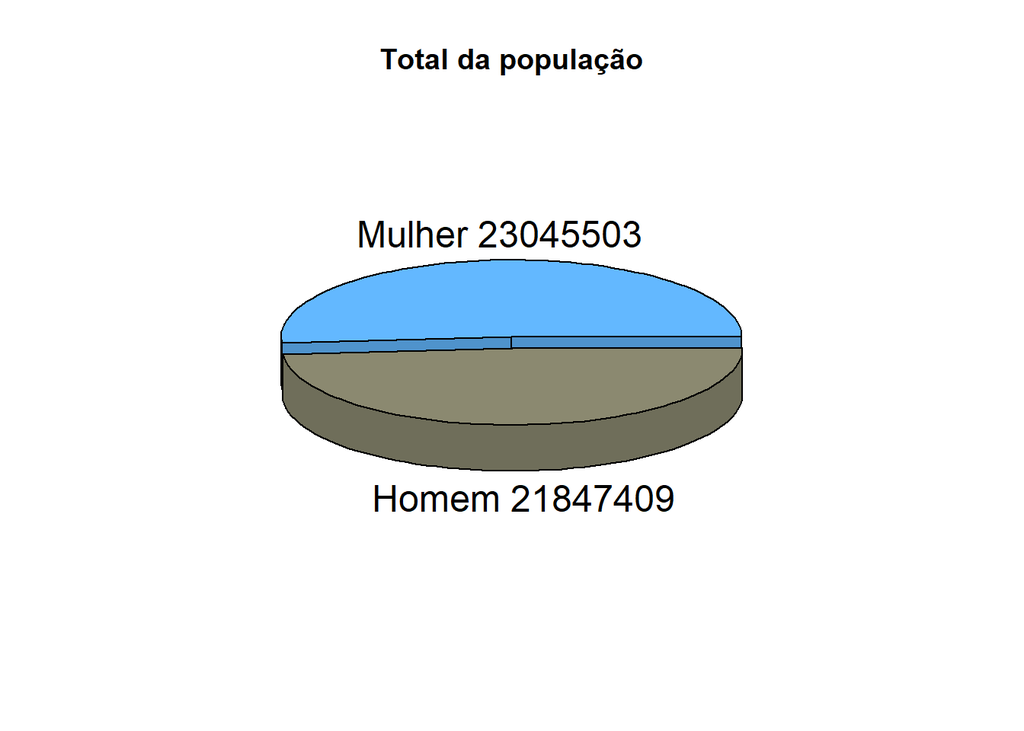

|  | Município | Mulher | Homem | Total |
| --- | --- | --- | --- | --- |
| 1 | ADAMANTINA | 17559 | 16310 | 33869 |
| 2 | ADOLFO | 1737 | 1699 | 3436 |
| 3 | AGUAI | 17864 | 18021 | 35885 |
| 4 | AGUAS DA PRATA | 3973 | 3834 | 7807 |
| 5 | AGUAS DE LINDOIA | 9466 | 8972 | 18438 |
| 6 | AGUAS DE SANTA BARBARA | 3045 | 2912 | 5957 |
| 7 | AGUAS DE SAO PEDRO | 1665 | 1479 | 3144 |
| 8 | AGUDOS | 18386 | 17869 | 36255 |
| 9 | ALAMBARI | 2935 | 2921 | 5856 |
| 10 | ALFREDO MARCONDES | 1925 | 1999 | 3924 |

[output cut: 635 more lines]

### 2.2.2 Informação da **Renda**

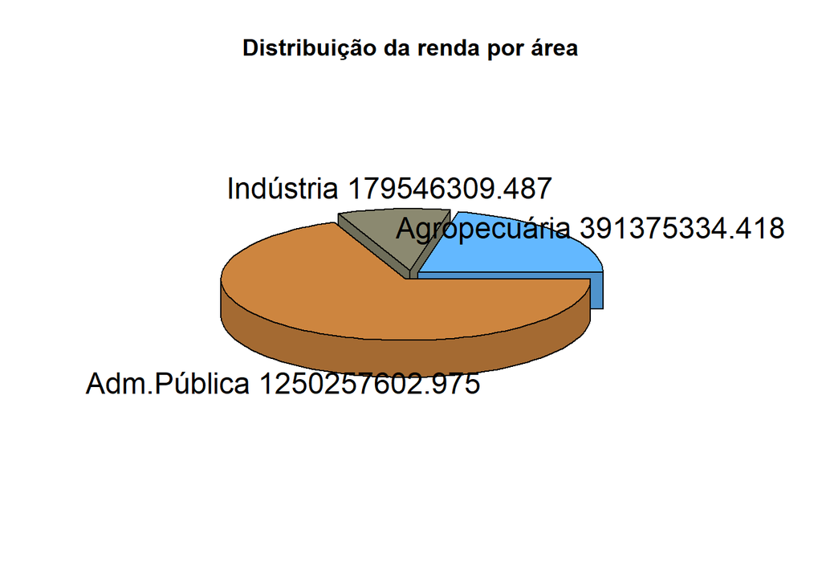

|  | Município | Agropecuária | Indústria | Adm.Pública | Total | PIB | Per Capita |
| --- | --- | --- | --- | --- | --- | --- | --- |
| 1 | ADAMANTINA | 131611.077 | 177739.356 | 655890.223 | 965240.656 | 83654.59 | 1084405.125 |
| 2 | ADOLFO | 11020.428 | 22193.631 | 33365.6 | 66579.659 | 3147.005 | 92373.72 |
| 3 | AGUAI | 314194.787 | 128003.309 | 361394.996 | 803593.092 | 122658.038 | 1008187.311 |
| 4 | AGUAS DA PRATA | 19332.606 | 32800.508 | 91830.977 | 143964.091 | 14356.201 | 168304.728 |
| 5 | AGUAS DE LINDOIA | 37780.141 | 89095.684 | 325597.328 | 452473.153 | 34178.982 | 491522.068 |
| 6 | AGUAS DE SANTA BARBARA | 9779.954 | 34090.678 | 64285.74 | 108156.372 | 8236.804 | 166830.491 |
| 7 | AGUAS DE SAO PEDRO | 10762.99 | 21328.628 | 96791.783 | 128883.401 | 7063.243 | 135946.643 |
| 8 | AGUDOS | 927745.501 | 177012.035 | 698059.548 | 1802817.084 | 323936.923 | 2203350.254 |
| 9 | ALAMBARI | 7398.26 | 25509.294 | 31981.97 | 64889.524 | 4634.974 | 100497.292 |
| 10 | ALFREDO MARCONDES | 13694.812 | 20357.646 | 29083.234 | 63135.692 | 15206.343 | 83372.758 |

[output cut: 635 more lines]

### 2.2.3 Informação das **Ocorrências Policiais**

Informações do ano de 2020 do Estado de São Paulo, agrupamento as ocorrências por Entorpecentes 51016.83, Armas 13274.722, Apreensão 62188.064 e Prisões 168955.82 totalizando um total de 295435.436. Também houve uma recuperação de veículos de 22456.659.

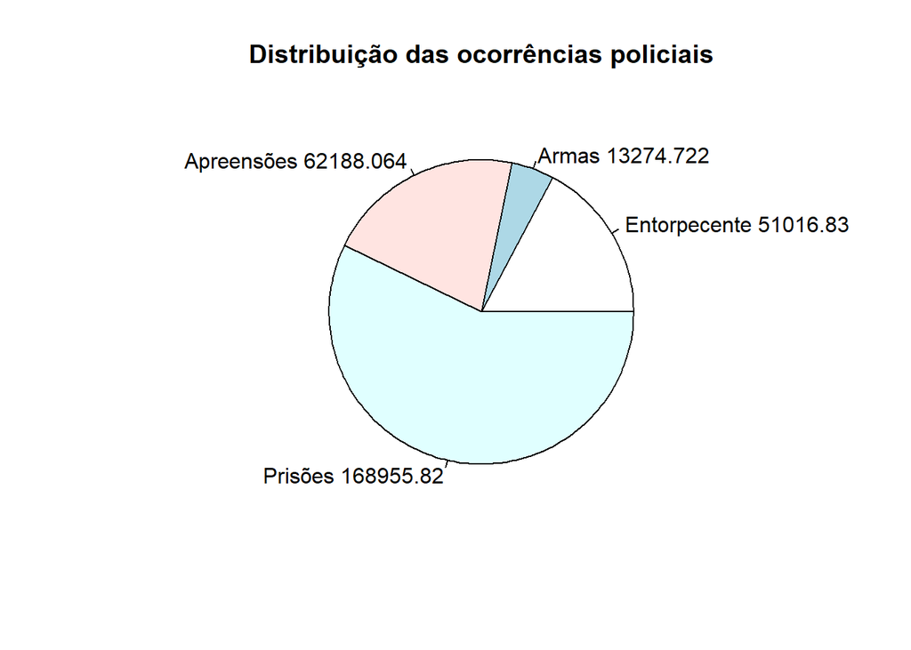

[interactive table not shown]

### 2.2.4 Informação da **Escolaridade**

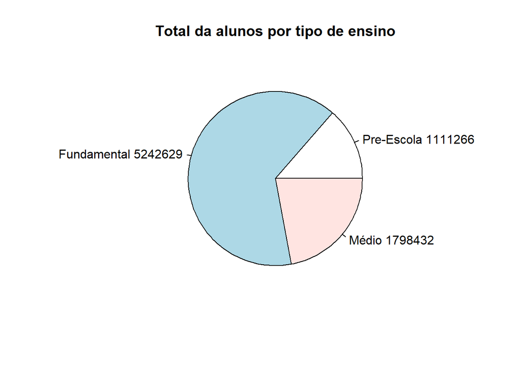

|  | Município. | Pre-Escola | Fundamental | Médio |
| --- | --- | --- | --- | --- |
| 1 | SAO PAULO | 295587 | 1329929 | 495714 |
| 2 | ADAMANTINA | 655 | 3530 | 1407 |
| 3 | ADOLFO | 90 | 455 | 147 |
| 4 | AGUAI | 823 | 4143 | 1073 |
| 5 | AGUAS DE LINDOIA | 491 | 1989 | 579 |
| 6 | AGUAS DA PRATA | 126 | 658 | 175 |
| 7 | AGUAS DE SAO PEDRO | 105 | 431 | 150 |
| 8 | AGUDOS | 1009 | 4695 | 1540 |
| 9 | ALFREDO MARCONDES | 99 | 386 | 138 |
| 10 | ALTAIR | 99 | 468 | 128 |

[output cut: 635 more lines]